# SAINTS - Sample size / power calculation - seroprevalance and seroincidence

Helen Dale

2022-09-05

## 1. Seroprevalance for serosurveys

### Method

Data simulated (100,000 simulations) based on a binomial distribution 200 children per 1 year age-band

Acceptable margin of error and confidence interval for estimation across all seroprevalences for 1000 single samples (200 in each of 5 age bands), as a minimum sample size for each site in Malawi, Kenya, Burkina Faso and Ghana.

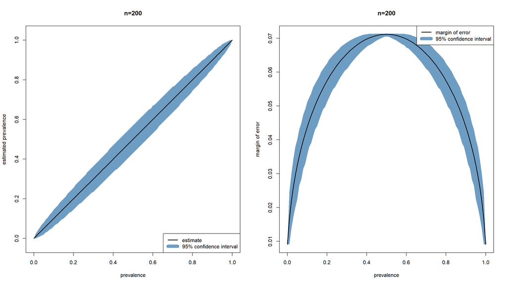

```r
par(mfrow=c(1,2))

plot(x,y,xlab="prevalence",ylab="estimated prevalence",col="black",type="l",lwd=2,asp=1,main="n=200")

tmpCol<-col2rgb("steelblue")
polygon(x=c(x,x[length(x):1]),y=c(yl,yu[length(x):1]),col=rgb(maxColorValue=255,red=tmpCol[1],green=tmpCol[2],blue=tmpCol[3],alpha=200),border=NA)
lines(x,y,col="black",lwd=2)

legend(x="bottomright",lty=c(1,1),lwd=c(2,10),col=c("black",rgb(maxColorValue=255,red=tmpCol[1],green=tmpCol[2],blue=tmpCol[3],alpha=200)),legend=c("estimate","95% confidence interval"))

plot(x,moe,col="black",type="l",lwd=2,main="n=200",xlab="prevalence",ylab="margin of error")
par(xpd=T)
tmpCol<-col2rgb("steelblue")
polygon(x=c(x,x[length(x):1]),y=c(moel,moeu[length(x):1]),col=rgb(maxColorValue=255,red=tmpCol[1],green=tmpCol[2],blue=tmpCol[3],alpha=200),border=NA)
lines(x,moe,col="black",lwd=2)
legend(x="topright",lty=c(1,1),col=c("black",rgb(maxColorValue=255,red=tmpCol[1],green=tmpCol[2],blue=tmpCol[3],alpha=200)),lwd=c(2,10),legend=c("margin of error","95% confidence interval"))
```

## 2. Power for detecting change in seroconversion rates

### Assumptions

- Salmonella shedding prevalence (i.e. the proportion of individuals which will test positive for Salmonella in stool at a given visit): $p_{sal}=8\%$

### Method

This is quite similar to testing for a difference in SBA between 2 groups, but now we compare a binary outcome (seroconversion) between the 2 groups. Additional assumption are be around what proportion of individuals are already seroconverted at the first sample and how many more are seroconverted at the second sample – we compute several scenarios here.

As before, we will use ready formulas (now for comparing proportions between 2 groups of unequal size), but the actual analysis in the study can be adjusted for e.g. age and other confounders.

### Results

```r
gr<-expand.grid(seq(1000,2500,by=100),c(0.1,0.15,0.2,0.25),c(0.2,0.3,0.4,0.5),c(1/24,0.074,0.08,0.099))

datPowSeroConv<-data.frame(
  alpha=0.05,
  prev=gr[,4],
  pDropOut=0.2,
  nTot=gr[,1],
  nTotComp=NA,
  n1=NA,
  n2=NA,
  p1=gr[,2],
  p2=gr[,3],
  power=NA
)

datPowSeroConv$nTotComp<-floor((1-datPowSeroConv$pDropOut)*datPowSeroConv$nTot)
datPowSeroConv<-datPowSeroConv[datPowSeroConv$p2/datPowSeroConv$p1<3 & datPowSeroConv$p2/datPowSeroConv$p1>1,]

datPowSeroConv$n1<-round(datPowSeroConv$prev*datPowSeroConv$nTotComp)
datPowSeroConv$n2<-round((1-datPowSeroConv$prev)*datPowSeroConv$nTotComp)
datPowSeroConv$p1p2<-factor(paste(sep="","p1 = ",datPowSeroConv$p1,", p2 = ",datPowSeroConv$p2))

for(j in 1:nrow(datPowSeroConv)){
  datPowSeroConv$power[j]<-pwr.2p2n.test(h=ES.h(p1=datPowSeroConv$p1[j],p2=datPowSeroConv$p2[j]),n1=datPowSeroConv$n1[j],n2=datPowSeroConv$n2[j])$power
}
```

Results below show that power is quite high for most scenarios, particularly when the effect of exposure results in a doubling or more of the seroconversion rate (i.e. p2 $\geq$ 2$\cdot$p1).

Note that the sample sizes go up to 2,500 on the graph below. The vertical dashed grey line indicates the 2,000 individuals that are planned to be recruited.

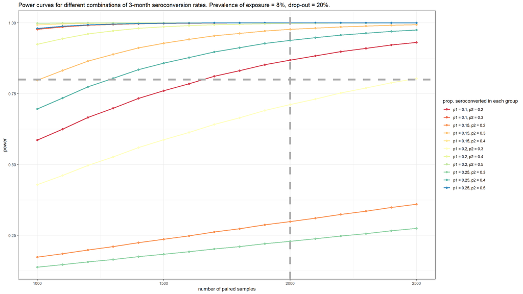

```r
ggplot(data=datPowSeroConv[datPowSeroConv$prev==0.08,],mapping=aes(x=nTot,y=power,group=p1p2,color=p1p2)) +
  geom_point(size=2) +
  geom_line(lwd=1) +
  scale_color_manual(values=colorRampPalette(brewer.pal(9,"Spectral"))(length(levels(datPowSeroConv$p1p2))),name="prop. seroconverted in each group") +
  geom_hline(yintercept=0.8,lwd=2,lty=2,col="darkgrey") +
  geom_vline(xintercept=2000,lwd=2,lty=2,col="darkgrey") +
  theme(legend.position = "right",text=element_text(size=16)) +
  xlab("number of paired samples") +
  ylab("power") +
  ggtitle("Power curves for different combinations of 3-month seroconversion rates. Prevalence of exposure = 8%, drop-out = 20%.") +
  theme_bw()
```

## 3. Power for detecting change in SBA due to Salmonella exposure

### Assumptions

- Salmonella shedding prevalence (i.e. the proportion of individuals which will test positive for Salmonella in stool at a given visit): $p_{sal}=8\%$

### Method

A stool sample will only be collected at the first visit and tested for presence of Salmonella. This allows splitting the data into 2 groups: those who are shedding Salmonella at the first visit and those who do not.

As exposure will have a delayed effect on immunity / SBA, only the second SBA measurement needs to be compared (but can use the SBA measurement from the first visit to adjust for unmeasured latent factors that result in some individuals having naturally higher or lower SBA).

From a sample size / power calculation point of view this means that we can use formulas for simple, unbalanced, two-sample t-tests (technically this assumes an unadjusted analysis, but it is common to do sample size calculations this way: adjustment - if needed - should increase power).

In R we calculate this using the function `pwr.t2n.test()` from the `pwr` package.

### Results

```r
gr<-expand.grid(seq(1000,2500,by=100),c(0.1,0.2),c(0.4,0.6),c(1/24,0.074,0.08,0.099))

datPowSalm<-data.frame(
  alpha=0.05,
  prev=gr[,4],
  pDropOut=0.2,
  nTot=gr[,1],
  nTotComp=NA,
  n1=NA,
  n2=NA,
  delta=gr[,2],
  sd=gr[,3],
  es=NA,
  power=NA
)

datPowSalm$nTotComp<-floor((1-datPowSalm$pDropOut)*datPowSalm$nTot)
datPowSalm$n1<-round(datPowSalm$prev*datPowSalm$nTotComp)
datPowSalm$n2<-round((1-datPowSalm$prev)*datPowSalm$nTotComp)
datPowSalm$es<-round(digits=2,datPowSalm$delta/datPowSalm$sd)

for(j in 1:nrow(datPowSalm)){
  datPowSalm$power[j]<-pwr.t2n.test(n1=datPowSalm$n1[j],n2=datPowSalm$n2[j],d=datPowSalm$es[j],sig.level=datPowSalm$alpha[j])$power
}

datPowSalm$EsSd<-factor(paste(sep="","ES = ",datPowSalm$delta,", SD = ",datPowSalm$sd))
```

As the results below show, power is quite high (99.97%) for a difference of 0.2 in SBA between the 2 groups, assuming 2,000 individuals, 20% drop-out, $\sigma_{SBA}=0.4$. If SBA has higher variance (e.g. $\sigma=0.6$ rather than $\sigma=0.4$), power will be reduced but still very high (94.73% for $\sigma_{SBA}=0.6$).

For smaller effect sizes (difference of 0.1 in SBA) power is lower (see graph).

Note that the sample sizes go up to 2,500 on the graph below. The vertical dashed grey line indicates the 2,000 individuals that are planned to be recruited.

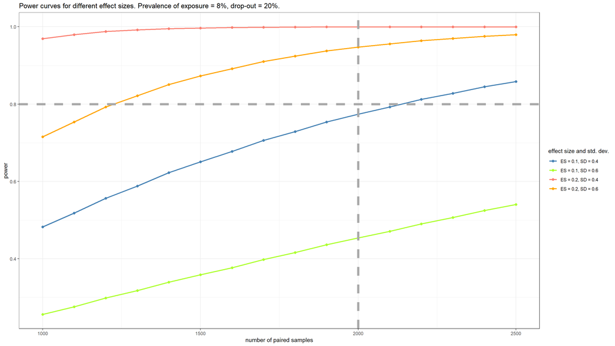

```r
ggplot(data=datPowSalm[datPowSalm$prev==0.08,],mapping=aes(x=nTot,y=power,group=EsSd,color=EsSd)) +
  geom_point(size=2) +
  geom_line(lwd=1) +
  scale_color_manual(values=c("steelblue","greenyellow","salmon","orange"),name="effect size and std. dev.") +
  geom_hline(yintercept=0.8,lwd=2,lty=2,col="darkgrey") +
  geom_vline(xintercept=2000,lwd=2,lty=2,col="darkgrey") +
  theme(legend.position = "right",text=element_text(size=16)) +
  xlab("number of paired samples") +
  ylab("power") +
  ggtitle("Power curves for different effect sizes. Prevalence of exposure = 8%, drop-out = 20%.")+
  theme_bw()
```